# Introduction

**Title: Practical Machine Learning Course Project**

**Author: Anshul Goyal**

**email: anshulgoyal2007@gmail.com**

**Data Credit: Velloso, E.; Bulling, A.; Gellersen, H.; Ugulino, W.; Fuks, H. Qualitative Activity Recognition of Weight Lifting Exercises. Proceedings of 4th International Conference in Cooperation with SIGCHI (Augmented Human '13) . Stuttgart, Germany: ACM SIGCHI, 2013.**

**http://groupware.les.inf.puc-rio.br/har**

# Introduction

The goal of the project is to predict how well people do exercise on the basis of data collected by wearable devices such as Jawbone Up, Nike FuelBand, and Fitbit. 6 participants were asked to perform barbell lifts correctly and incorrectly in 5 different ways. This information “classe” is the target of this project. Data from accelerometers on the belt, forearm, arm, and dumbell is used as explanatory data.

# Preparing the workbench

Loading all the packages and functions required for the project. Set the working directory and loading the data

- dev: Development data
- pred: Prediction data

```r
rm(list=ls())
# Loading Packages
library(ggplot2)
library(caret)
library(randomForest)
library(gbm)
library(mlearning)
library(corrplot)
library(lattice)

# Functions
pml_write_files = function(x){
  n = length(x)
  for(i in 1:n){
    filename = paste0("problem_id_",i,".txt")
    write.table(x[i],file=filename,quote=FALSE,row.names=FALSE,col.names=FALSE)
  }
}
```

###Load Data

```r
# Working Directory
setwd("C:/Users/anshul/Desktop/Education/C_p_m_l/assignment")

#Data Load
dev <- read.csv("pml-training.csv", na.strings = c("NA", ""))
pred <- read.csv("pml-testing.csv", na.strings = c("NA", ""))
```

# Creating train and test data

```r
# creating testing(70%) & training(30%)
set.seed(1234)
inTrain <- createDataPartition(y=dev$classe, p=0.7, list=F)
training <- dev[inTrain,]
testing <- dev[-inTrain,]
```

# Cleaning and variable selection

### Removing index and timestamps variables

```r
### Removing index and timestamps variables
training <- training[,-(1:5)]
testing <- testing[,-(1:5)]
pred <- pred[,-(1:5)]
```

### Removing variables with excessive “NA”, removing variables with over 90% missing

```r
keep.vars <- (apply(is.na(training), 2, mean) <= 0.9)
training <- training[,keep.vars]
testing <- testing[,keep.vars]
pred <- pred[,keep.vars] #last variable is problem_id
names(training)==names(pred) #check for variable names in development data and prediction data
```

### Removing variables with nero zero variance

```r
N <- nearZeroVar(training,saveMetrics=T)
N[N$nzv==1,]
```

```
##            freqRatio percentUnique zeroVar  nzv
## new_window     47.37       0.01456   FALSE TRUE
```

Removing following variable from predictors

- new_window

```r
training <- training[,-1]
testing <- testing[,-1]
pred <- pred[,-1] #last variable is problem_id
```

### Matching the class of variables in training and prediction dataset

```r
type.summ <- matrix(0,dim(training)[2],5)
colnames(type.summ) <- c("num","variable","same_class", "same_type", "type_training")
for (i in 1:dim(training)[2]){
  type.summ[i,1] <- i
  type.summ[i,2] <- names(training)[i]
  type.summ[i,3] <- (class(pred[,i]) == class(training[,i]))
  type.summ[i,4] <- (typeof(pred[,i]) == typeof(training[,i]))
  type.summ[i,5] <- class(training[,i])
}

print(type.summ[type.summ[,3]==F,])
```

```
##      num  variable            same_class same_type type_training
## [1,] "40" "magnet_dumbbell_z" "FALSE"    "FALSE"   "numeric"
## [2,] "52" "magnet_forearm_y"  "FALSE"    "FALSE"   "numeric"
## [3,] "53" "magnet_forearm_z"  "FALSE"    "FALSE"   "numeric"
## [4,] "54" "classe"            "FALSE"    "TRUE"    "factor"
```

Changing the class of variables in prediction dataset to make it consistent with training

- magnet_dumbbell_z
- magnet_forearm_y
- magnet_forearm_z

```r
pred[,40] <- as.numeric(pred[,40])
pred[,52] <- as.numeric(pred[,52])
pred[,53] <- as.numeric(pred[,53])
```

### Correlation of independent variables

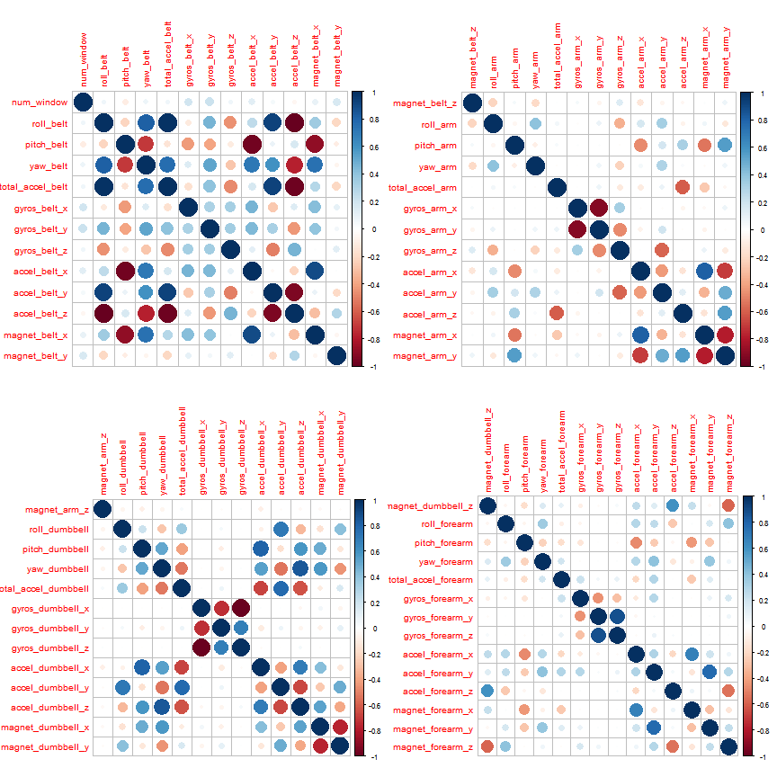

```r
par(mfrow=c(2,2))
M1 <- cor(training[,1:13])
M2 <- cor(training[,14:26])
M3 <- cor(training[,27:39])
M4 <- cor(training[,40:53])
corrplot(M1, method = "circle")
corrplot(M2, method = "circle")
corrplot(M3, method = "circle")
corrplot(M4, method = "circle")
```

# Modeling

Developing random forest with 100 trees and default parameters

### Creating the modeling equation

```r
# independent variables: total 53 independent variables
var.ind <- names(training[,-54])
#target variable
var.tar <- "classe"

mdl.eq <- as.formula(paste(var.tar,"~", paste(c(var.ind), collapse = " + "), sep =""))
print(mdl.eq)
```

```
## classe ~ num_window + roll_belt + pitch_belt + yaw_belt + total_accel_belt +
##     gyros_belt_x + gyros_belt_y + gyros_belt_z + accel_belt_x +
##     accel_belt_y + accel_belt_z + magnet_belt_x + magnet_belt_y +
##     magnet_belt_z + roll_arm + pitch_arm + yaw_arm + total_accel_arm +
##     gyros_arm_x + gyros_arm_y + gyros_arm_z + accel_arm_x + accel_arm_y +
##     accel_arm_z + magnet_arm_x + magnet_arm_y + magnet_arm_z +
##     roll_dumbbell + pitch_dumbbell + yaw_dumbbell + total_accel_dumbbell +
##     gyros_dumbbell_x + gyros_dumbbell_y + gyros_dumbbell_z +
##     accel_dumbbell_x + accel_dumbbell_y + accel_dumbbell_z +
##     magnet_dumbbell_x + magnet_dumbbell_y + magnet_dumbbell_z +
##     roll_forearm + pitch_forearm + yaw_forearm + total_accel_forearm +
##     gyros_forearm_x + gyros_forearm_y + gyros_forearm_z + accel_forearm_x +
##     accel_forearm_y + accel_forearm_z + magnet_forearm_x + magnet_forearm_y +
##     magnet_forearm_z
```

### Cross validation for tuning mtry

5 fold cross validation to choose mtry

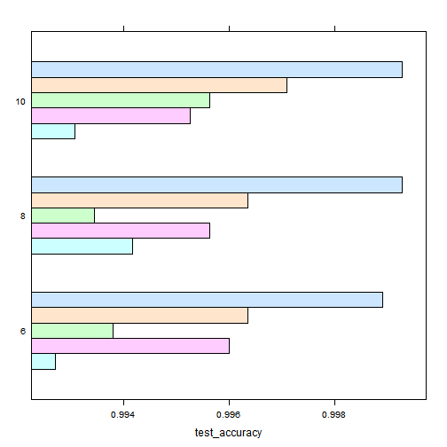

```r
set.seed(5758)
folds <- createFolds(y=training$classe, k=5, list=T, returnTrain=T)
mtry.lst <- c("6","8", "10")
track.mtx <- matrix(0,length(mtry.lst)*5,4)
colnames(track.mtx) <- c("mtry","fold","train_accuracy", "test_accuracy")
for (mm in 1:length(mtry.lst)){
  for (ii in 1:5){
    mtry.lst.num <- as.numeric(mtry.lst[mm])
    rf.tr <- training[folds[[ii]],]
    rf.ts <- training[-folds[[ii]],]

    rf.mdl.cr.val = randomForest(mdl.eq, data = rf.tr, ntree = 100, mtry=mtry.lst.num)

    rf.tr$classe_pred_cr <- predict(rf.mdl.cr.val,rf.tr)
    rf.ts$classe_pred_cr <- predict(rf.mdl.cr.val,rf.ts)
    track.mtx[(mm-1)*5+ii,1] <- mtry.lst.num
    track.mtx[(mm-1)*5+ii,2] <- ii
    track.mtx[(mm-1)*5+ii,3] <- table(rf.tr$classe_pred_cr==rf.tr$classe)[2]/dim(rf.tr)[1]
    track.mtx[(mm-1)*5+ii,4] <- table(rf.ts$classe_pred_cr==rf.ts$classe)[2]/dim(rf.ts)[1]
  }
}

# Plot the results from cross validation
barchart(factor(mtry) ~ test_accuracy,data=as.data.frame(track.mtx),groups=fold)
```

```r
mean(track.mtx[1:5,4])
```

```
## [1] 0.9956
```

```r
mean(track.mtx[6:10,4])
```

```
## [1] 0.9958
```

```r
mean(track.mtx[11:15,4])
```

```
## [1] 0.9961
```

```r
mtry.best <- 10
```

### Final Random Forest

```r
set.seed(1234)
rf.mdl = randomForest(mdl.eq, data = training, ntree = 100, mtry =mtry.best, do.trace = T, importance= TRUE)

# Prediction: classe_pred
training$classe_pred <- predict(rf.mdl,training)
testing$classe_pred <- predict(rf.mdl,testing)
```

### Variable Importance: Top 10 variables

```r
var.imp <- rf.mdl$importance
var.imp <- var.imp[order(-var.imp[,6]),]
var.imp.mtr <- row.names(var.imp)[1:10]
data.frame(var.imp.mtr)
```

```
##          var.imp.mtr
## 1         num_window
## 2          roll_belt
## 3  magnet_dumbbell_y
## 4       roll_forearm
## 5  magnet_dumbbell_z
## 6           yaw_belt
## 7  magnet_dumbbell_x
## 8         pitch_belt
## 9      pitch_forearm
## 10     roll_dumbbell
```

### Feature plot of top 10 variables

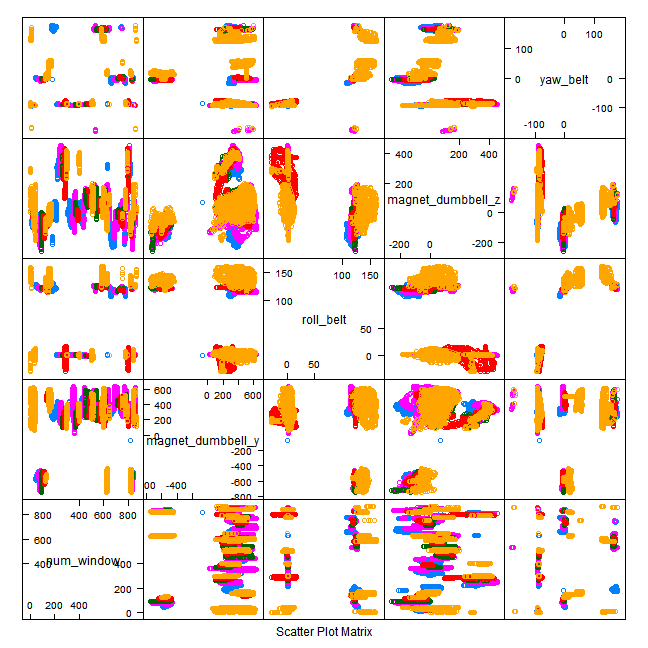

```r
featurePlot(x=training[,c("num_window","magnet_dumbbell_y","roll_belt", "magnet_dumbbell_z", "yaw_belt")],y=training$classe ,plot="pairs")
```

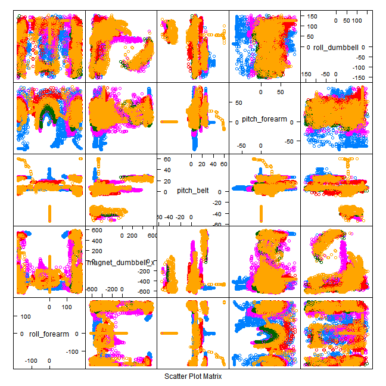

```r
featurePlot(x=training[,c("roll_forearm","magnet_dumbbell_x","pitch_belt", "pitch_forearm", "roll_dumbbell")],y=training$classe ,plot="pairs")
```

### confusion Matrix

```r
print(confusionMatrix(testing$classe_pred,testing$classe))
```

```
## Confusion Matrix and Statistics
##
##           Reference
## Prediction    A    B    C    D    E
##          A 1674    3    0    0    0
##          B    0 1136    4    0    0
##          C    0    0 1021    4    0
##          D    0    0    1  959    0
##          E    0    0    0    1 1082
##
## Overall Statistics
##
##                Accuracy : 0.998
##                  95% CI : (0.996, 0.999)
##     No Information Rate : 0.284
##     P-Value [Acc > NIR] : <2e-16
##
##                   Kappa : 0.997
##  Mcnemar's Test P-Value : NA
##
## Statistics by Class:
##
##                      Class: A Class: B Class: C Class: D Class: E
## Sensitivity             1.000    0.997    0.995    0.995    1.000
## Specificity             0.999    0.999    0.999    1.000    1.000
## Pos Pred Value          0.998    0.996    0.996    0.999    0.999
## Neg Pred Value          1.000    0.999    0.999    0.999    1.000
## Prevalence              0.284    0.194    0.174    0.164    0.184
## Detection Rate          0.284    0.193    0.173    0.163    0.184
## Detection Prevalence    0.285    0.194    0.174    0.163    0.184
## Balanced Accuracy       1.000    0.998    0.997    0.997    1.000
```

```r
print(confusionMatrix(testing$classe_pred,testing$classe))
```

```
## Confusion Matrix and Statistics
##
##           Reference
## Prediction    A    B    C    D    E
##          A 1674    3    0    0    0
##          B    0 1136    4    0    0
##          C    0    0 1021    4    0
##          D    0    0    1  959    0
##          E    0    0    0    1 1082
##
## Overall Statistics
##
##                Accuracy : 0.998
##                  95% CI : (0.996, 0.999)
##     No Information Rate : 0.284
##     P-Value [Acc > NIR] : <2e-16
##
##                   Kappa : 0.997
##  Mcnemar's Test P-Value : NA
##
## Statistics by Class:
##
##                      Class: A Class: B Class: C Class: D Class: E
## Sensitivity             1.000    0.997    0.995    0.995    1.000
## Specificity             0.999    0.999    0.999    1.000    1.000
## Pos Pred Value          0.998    0.996    0.996    0.999    0.999
## Neg Pred Value          1.000    0.999    0.999    0.999    1.000
## Prevalence              0.284    0.194    0.174    0.164    0.184
## Detection Rate          0.284    0.193    0.173    0.163    0.184
## Detection Prevalence    0.285    0.194    0.174    0.163    0.184
## Balanced Accuracy       1.000    0.998    0.997    0.997    1.000
```

**Expected out of sample accuracy is 99.8%**

# Prediction (on out of sample 20 records)

```r
pred$classe_pred <- predict(rf.mdl, pred)
pred <- pred[order(pred$problem_id),]
answers = pred$classe_pred
pml_write_files(answers)
```